# Travelling Salesman Problem

Rebecca Wang

04/30/2019

### Introduction

NP-complete problem is a class of computational problems for which no efficient solution algorithm has been found. Some examples include CLIQUE, INDEPENDENT SET, SAT, and VERTEX COVER. In this blog post, I’ll introduce one more NP-complete problem: Travelling Salesman (TSP), important in operations research and theoretical computer science. I will discuss the Christofides algorithm, an approximation algorithm for the TSP.

### The Problem

The TSP asks the following question: **Given a list of cities and the distances between each pair of cities, what is the shortest possible route that visits each city and returns to the origin city?**

The decision version of the problem is NP-complete.

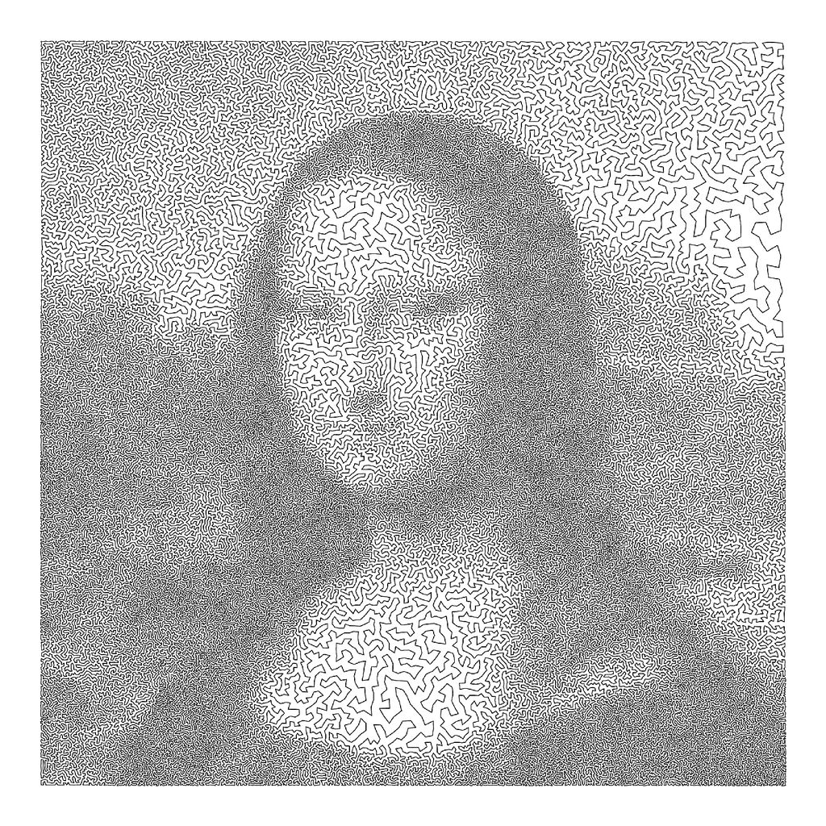

In February 2009, Robert Bosch created a 100,000-city instance of the traveling salesman problem (TSP) that provides a representation of Leonardo da Vinci’s Mona Lisa as a continuous-line drawing.[^1]

### Coping with NP-complete Problems like TSP

The theory says you aren’t likely to find a polynomial algorithm for an NP-complete problem. Should you just give up? Probably not, if your job depends on it.

One way to cope with these problems is [approximation algorithms](https://en.wikipedia.org/wiki/Approximation_algorithm). They are efficient algorithms that find approximate solutions to NP-hard optimization problems with provable guarantees on the distance of the returned solution to the optimal one.[^2]

### Christofides Algorithm

The Christofides algorithm is one of the approximation algorithms for TSP on instances where the distances form a metric space (they are symmetric and obey the triangle inequality). It guarantees a TSP tour which is at most 1.5 times the optimal. The algorithm is named after Nicos Christofides, who published it in 1976.[^3] As of 2017, this is the best approximation ratio that has been proven for the traveling salesman problem on general metric spaces, although better approximations are known for some special cases[^4].

The big ideas behind this algorithm are **the minimum spanning tree** and **minimum-weight perfect matching**.

Let G = (V,w) be an instance of the travelling salesman problem. That is, G is a complete graph on the set V of vertices, and the function w assigns a nonnegative real weight to every edge of G. According to the triangle inequality, for every three vertices u, v, and x, it should be the case that w(uv) + w(vx) ≥ w(ux).

Then the algorithm can be described in pseudocode as follows.[^5]

1. Create a [minimum spanning tree](https://en.wikipedia.org/wiki/Minimum_spanning_tree) T of G.
2. Let O be the set of vertices with odd degrees in T. By the handshaking lemma, O has an even number of vertices.
3. Find a minimum-weight perfect matching M in the [induced subgraph](https://en.wikipedia.org/wiki/Induced_subgraph) given by the vertices from O.
4. Combine the edges of M and T to form a connected multigraph H in which each vertex has even degree.
5. Form a [Eulerian circuit](https://en.wikipedia.org/wiki/Eulerian_path) in H.
6. Make the circuit found in the previous step into a [Hamiltonian circuit](https://en.wikipedia.org/wiki/Hamiltonian_path) by skipping repeated vertices (shortcutting).

### Example Following These Steps

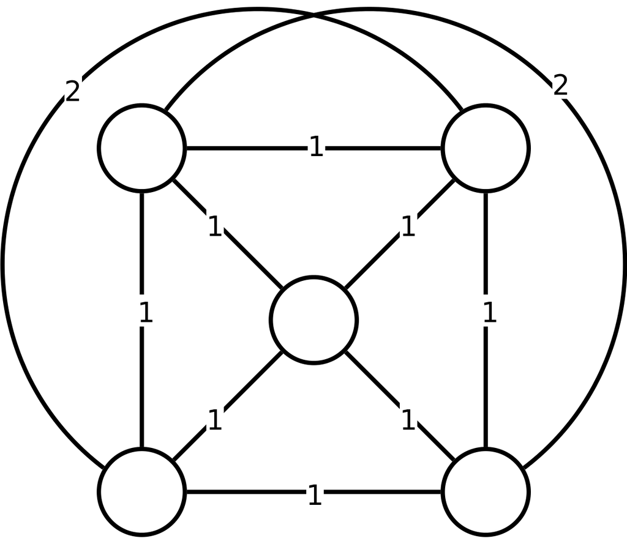

Given: complete graph whose edge weights obey the triangle inequality

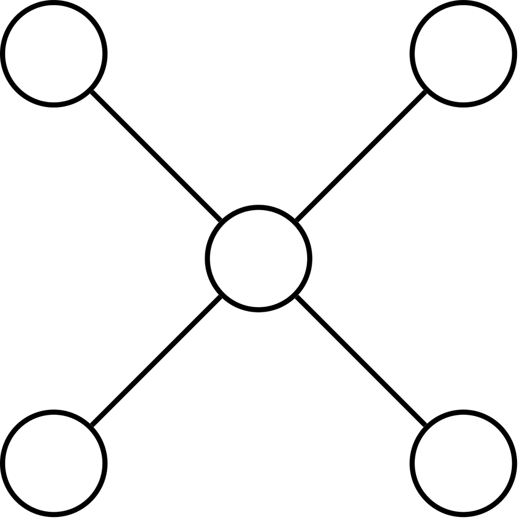

Calculate [minimum spanning tree](https://en.wikipedia.org/wiki/Minimum_spanning_tree) T

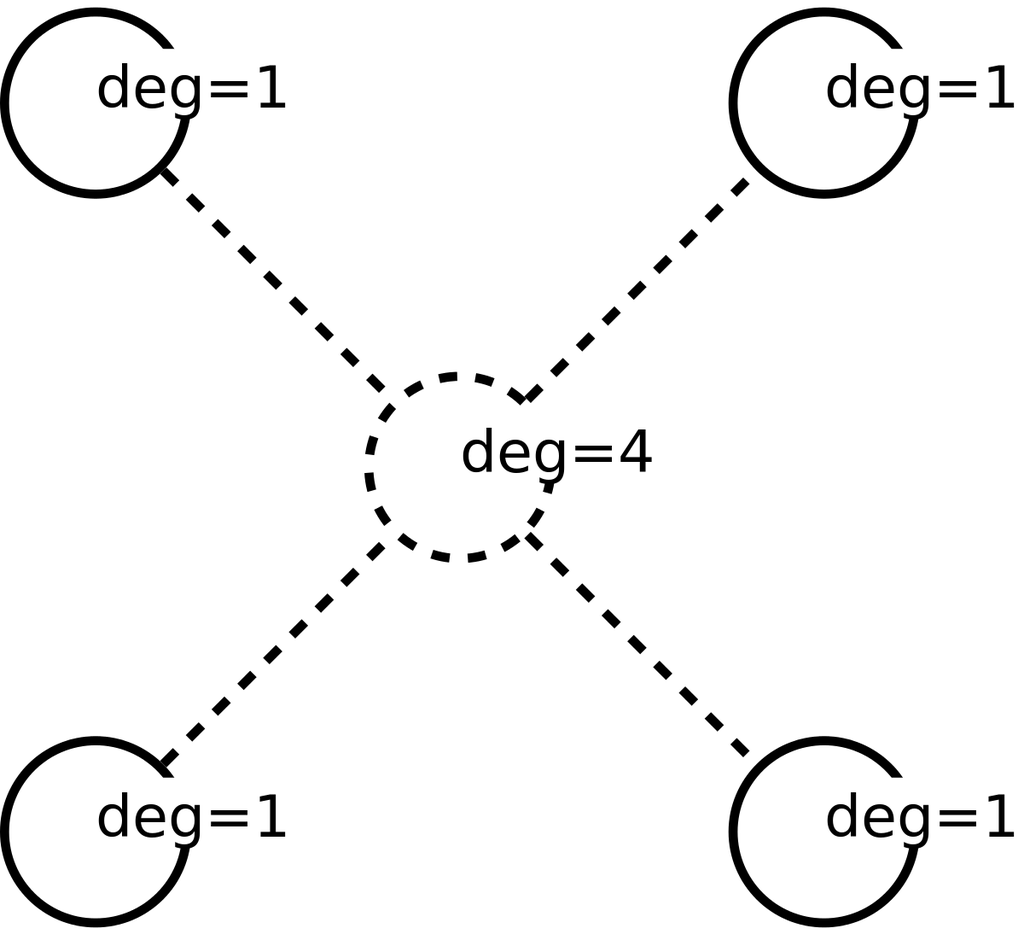

Calculate the set of vertices O with odd degrees in T

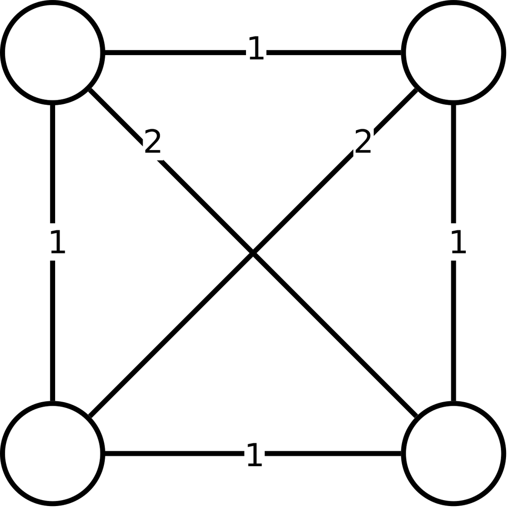

Form the [induced subgraph](https://en.wikipedia.org/wiki/Induced_subgraph) of G using only the vertices of O

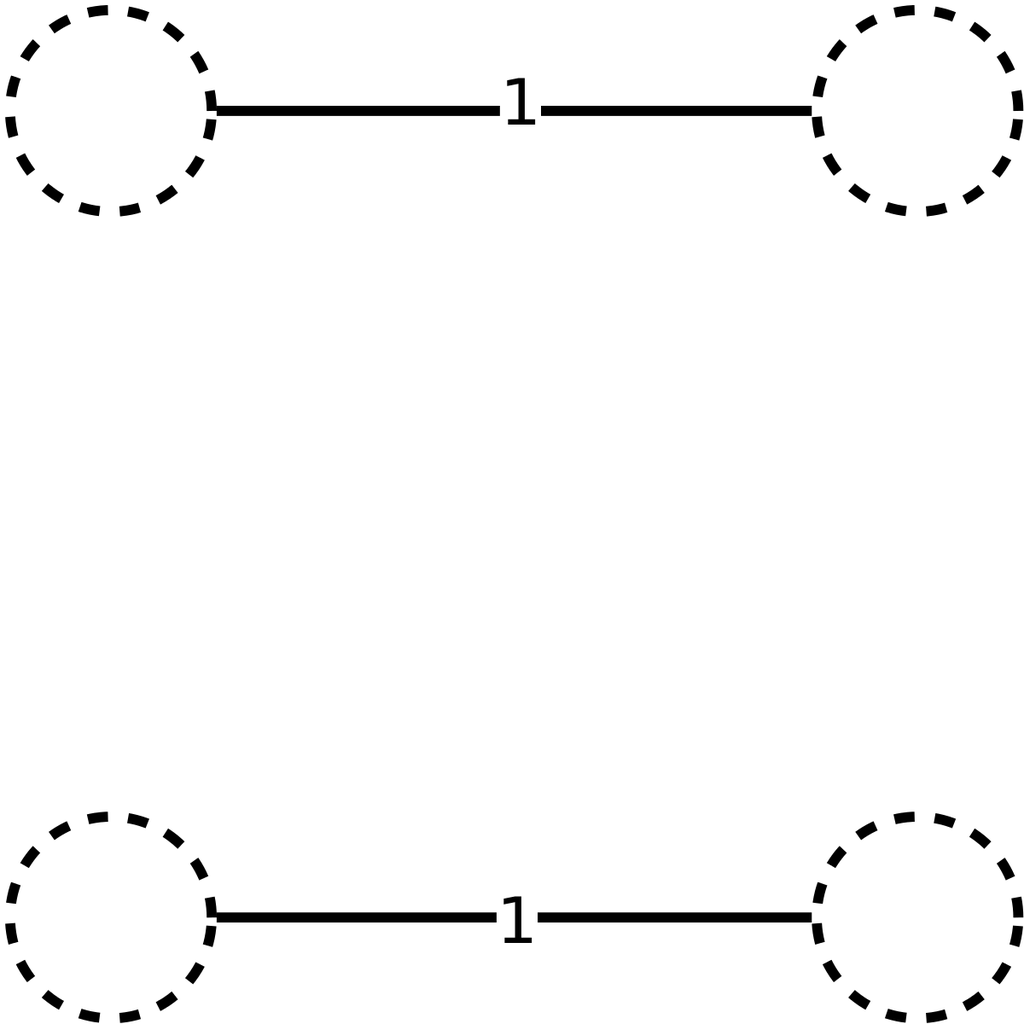

Construct a minimum-weight perfect matching M in this subgraph

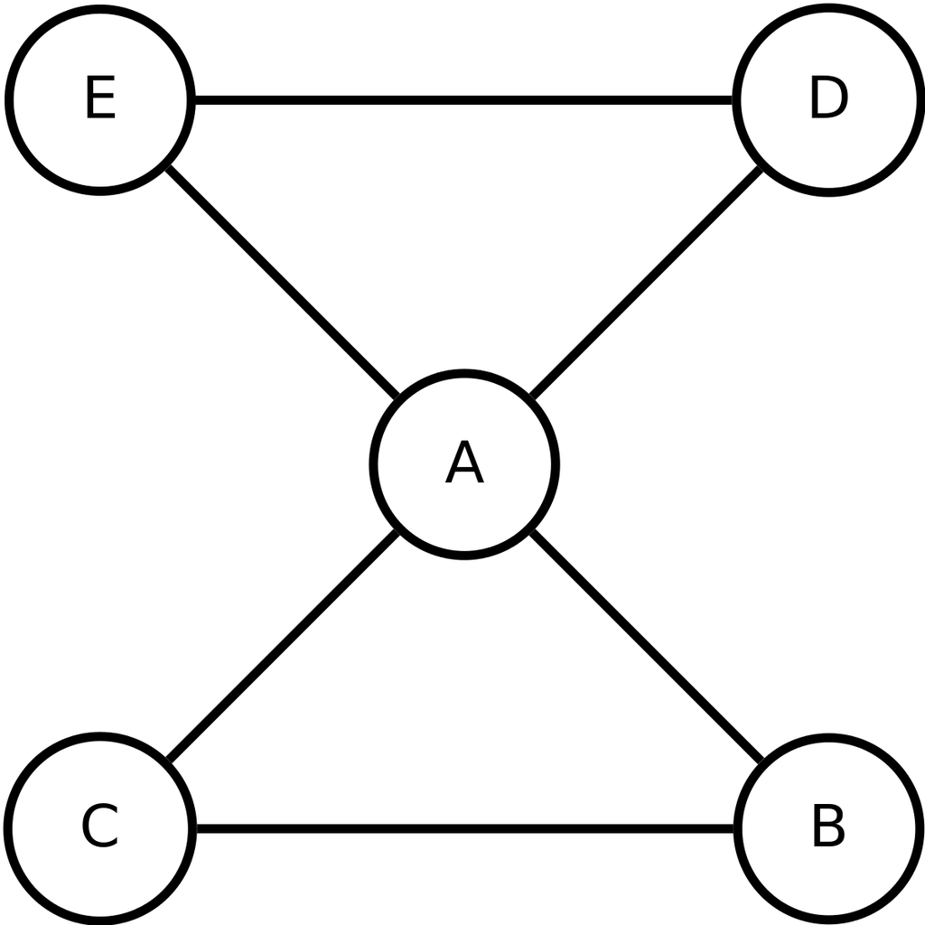

Unite matching and spanning tree to form a Eulerian multigraph

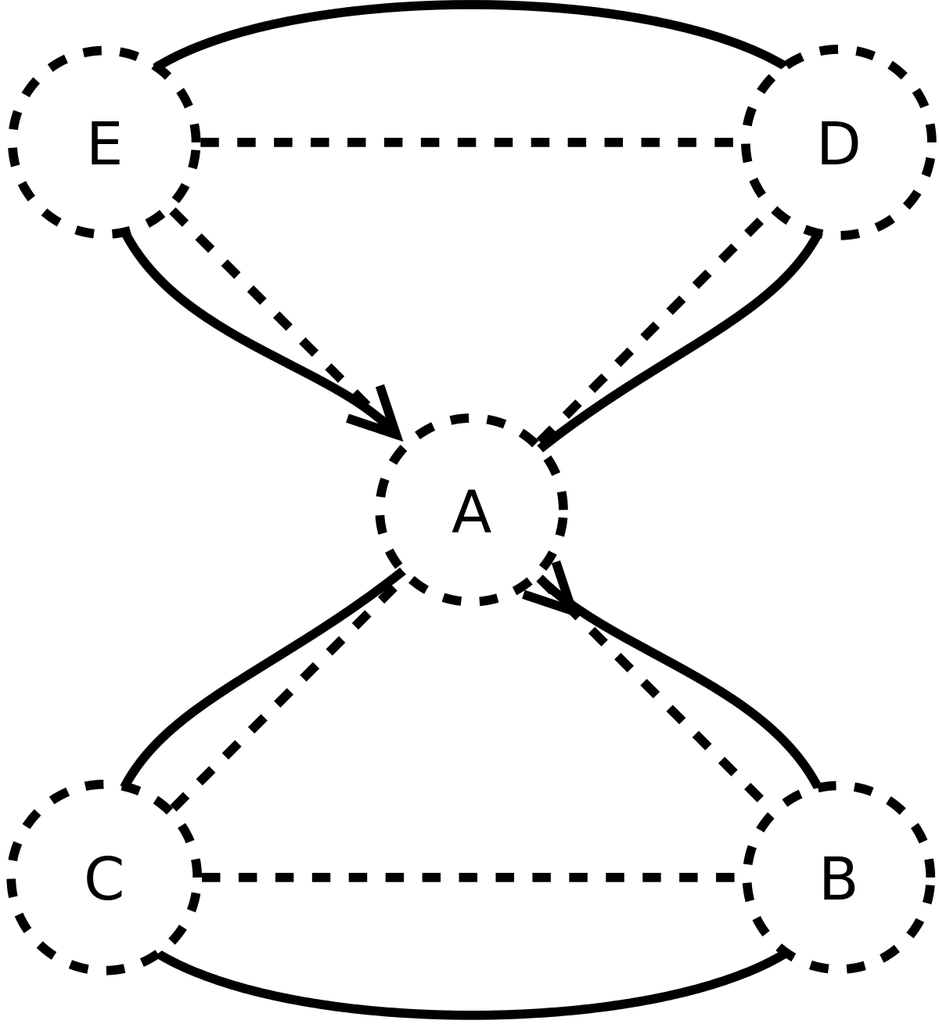

Calculate Euler tour

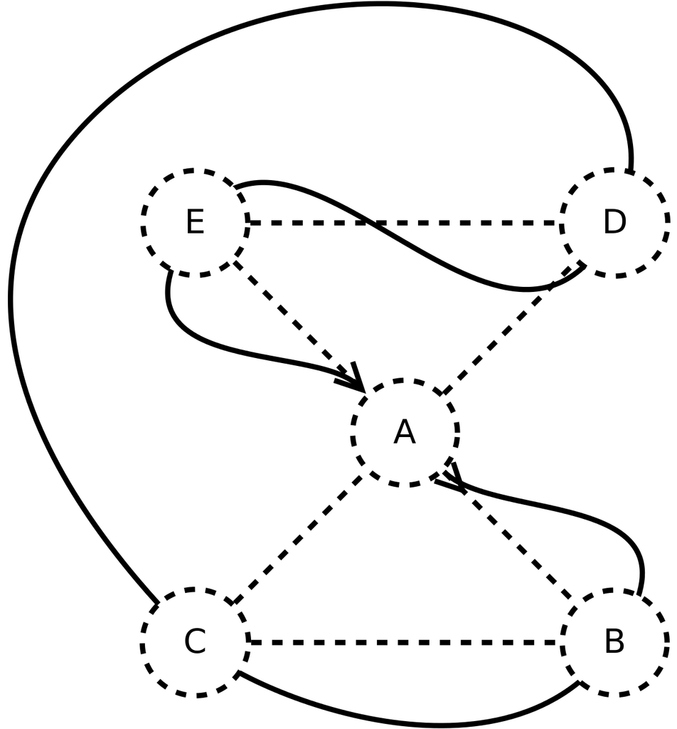

Remove repeated vertices, giving the algorithm’s output

### My Evaluation

First of all, the algorithm is **simple**. When it was created, many computer scientists assumed it was a placeholder that would eventually give way to a more sophisticated algorithm able to better approximate the true solution. Yet for decades, that algorithm failed to materialize.[^6]

Moreover, Christofides algorithm starts by looking not for the shortest round-trip route, but the shortest spanning tree — a collection of branches linking the cities, with no closed loops. Then it goes from a tree to a circuit. I think this is a brilliant idea.

### Main Contribution and Takeaway

Christofides algorithm provides the best approximation ratio (1.5 times the optimal) that has been proven for the traveling salesman problem, although better approximations are known for some special cases.

It is also one of the first approximation algorithms, and was in part responsible for drawing attention to approximation algorithms as a practical approach to intractable problems.[^7]

The TSP has several applications, including planning, manufacture of microchips, DNA sequencing, and astronomy. In these cases, the city may represent, for example, customers, soldering points, or DNA fragments; and distance may represent travelling times or cost, or a similarity measure between DNA fragments.

### Areas for Future Improvement

Though Christofides algorithm satisfies our objective of finding a good solution close to the shortest possible route, the approximation ratio still has room for improvement. With the infusion of new ideas into theoretical computer science, hopefully, we will see more results with better approximations for the TSP.

### Original Paper and Additional Readings

- [The original paper by Nicos Christofides](https://apps.dtic.mil/dtic/tr/fulltext/u2/a025602.pdf)
- [Computer Scientists Take Road Less Traveled](https://www.quantamagazine.org/computer-scientists-find-new-shortcuts-to-traveling-salesman-problem-20130129/)
- [Human Performance On The Traveling Salesman Problem](https://web.archive.org/web/20091229053516/http://www.psych.lancs.ac.uk/people/uploads/TomOrmerod20030716T112601.pdf)
[^1]: Reference: Mona Lisa TSP Challenge http://www.math.uwaterloo.ca/tsp/data/ml/monalisa.html
[^2]: Reference: Wikipedia https://en.wikipedia.org/wiki/Approximation_algorithm
[^3]: Original Paper https://apps.dtic.mil/dtic/tr/fulltext/u2/a025602.pdf
[^4]: Reference: Wikipedia https://en.wikipedia.org/wiki/Christofides_algorithm
[^5]: Reference: Goodrich, Michael T.; Tamassia, Roberto (2015), “18.1.2 The Christofides Approximation Algorithm”, Algorithm Design and Applications, Wiley, pp. 513–514.
[^6]: Reference: Computer Scientists Take Road Less Traveled https://www.quantamagazine.org/computer-scientists-find-new-shortcuts-to-traveling-salesman-problem-20130129/
[^7]: Reference: Wikipedia https://en.wikipedia.org/wiki/Travelling_salesman_problem